##### Hipotesis

La arquitectura de raíces con presencia de malformaciones o abultamientos irregulares en la base del tallo no afecta el crecimiento y desarrollo de Taxodium mucronatum Ten

Comparación entre Niveles de deformación contra Crecimiento-Desarrollo para los 43 Árboles, considerando el Crecimiento-Desarrollo como las variables Altura (m), Diametro (m), Captura de Carbono (Ton), Cobertura copa (m).

Se muestran algunos datos obtenidos de 25 de los 43 Árboles de estudio.

Muestra de 25 de los 43 Árboles

| Árbol | No Placa | Altura (m) | Diametro (m) | Captura_Carbono (Ton) | Cobertura copa (m) | Nivel de deformación |
| --- | --- | --- | --- | --- | --- | --- |
| 1 | XVII-002 | 12.1 | 1.57 | 0.71 | 9.95 | Moderado |
| 2 | XVII-007 | 11.9 | 1.64 | 0.76 | 11.85 | Bajo |
| 3 | XVII-008 | 10.6 | 1.06 | 0.28 | 8.35 | Bajo |
| 4 | XVII-009 | 12.3 | 1.55 | 0.70 | 9.50 | Moderado |
| 5 | XVII-013 | 12.6 | 1.89 | 1.08 | 9.60 | Bajo |
| 6 | XVII-015 | 13.3 | 1.70 | 0.92 | 11.40 | Moderado |
| 7 | XVII-017 | 12.0 | 1.44 | 0.59 | 11.60 | Bajo |
| 8 | XVII-018 | 12.5 | 1.27 | 0.48 | 10.00 | Moderado |
| 9 | XVII-019 | 9.1 | 1.16 | 0.29 | 9.15 | Bajo |
| 10 | XVII-020 | 13.9 | 1.26 | 0.52 | 8.90 | Bajo |
| 11 | XVII-021 | 10.3 | 1.61 | 0.64 | 10.00 | Bajo |
| 12 | XVII-023 | 13.2 | 1.67 | 0.87 | 13.00 | Bajo |
| 13 | XVII-026 | 13.9 | 1.79 | 1.06 | 10.45 | Moderado |
| 14 | XVII-027 | 15.1 | 2.06 | 1.53 | 11.90 | Bajo |
| 15 | XVII-028 | 11.3 | 2.12 | 1.21 | 9.60 | Moderado |
| 16 | XVII-031 | 10.9 | 1.72 | 0.77 | 11.90 | Alto |
| 17 | XVII-032 | 10.5 | 1.52 | 0.58 | 11.65 | Severo |
| 18 | XVII-034 | 15.0 | 2.04 | 1.49 | 13.90 | Bajo |
| 19 | XVII-035 | 14.1 | 1.72 | 1.00 | 11.80 | Moderado |
| 20 | XVII-036 | 14.4 | 1.88 | 1.22 | 10.50 | Bajo |
| 21 | XVII-037 | 11.5 | 1.40 | 0.54 | 8.60 | Moderado |
| 22 | XVII-038 | 9.5 | 1.40 | 0.45 | 8.05 | Alto |
| 23 | XVII-041 | 11.4 | 1.86 | 0.94 | 11.20 | Alto |
| 24 | XVII-042 | 14.4 | 2.14 | 1.57 | 11.80 | Bajo |
| 25 | XVII-043 | 14.2 | 2.87 | 2.80 | 15.60 | Moderado |

A continuacion se hace una comparacion entre medias de Crecimiendo-Desarrollo para los diferentes tipos de malformaciones, mediante la prueba de Tukey

```
##   Tukey multiple comparisons of means
##     95% family-wise confidence level
##
## Fit: aov(formula = ajuste)
##
## $`DatosA$`Nivel de deformación``
##                       diff          lwr       upr     p adj
## Bajo-Alto        5.8035693  -0.06239137 11.669530 0.0534054
## Moderado-Alto    5.0043868  -1.13711948 11.145893 0.1449100
## Severo-Alto      1.1648673  -7.44400941  9.773744 0.9833815
## Moderado-Bajo   -0.7991825  -4.86649439  3.268129 0.9519653
## Severo-Bajo     -4.6387020 -11.91453079  2.637127 0.3319711
## Severo-Moderado -3.8395196 -11.33927218  3.660233 0.5229553
```

Donde “diff” es la diferencia entre las medias del correspondiente nivel de deformación que se compara, el intervalo de confianza para la respectiva diferencia de medias esta dada por (“lwr”, “upr”), y el P-valor esta dado por “p adj”

Los datos anteriores se resumen en el siguiente gráfico

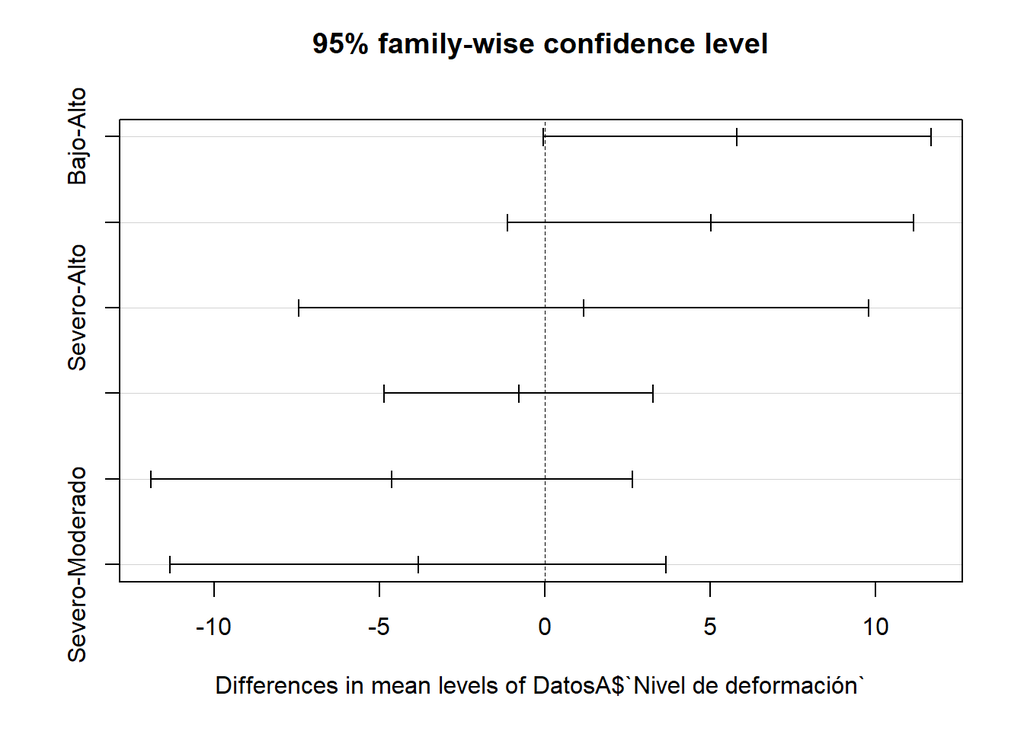

Como todas las comparaciones contienen al cero en su intervalo, se puede considarar que la diferencia entre las medias o promedios es estadisticamente cero, es decir, no son estadisticamente diferentes. Lo cual nos indica que el Crecimiento-Desarrollo es el mismo estadisticamente para los niveles de deformación, con lo que se concluye que; la arquitectura de raíces con presencia de malformaciones o abultamientos irregulares en la base del tallo, no afecta el crecimiento y desarrollo de Taxodium mucronatum Ten

Otra manera; es mediante comparación de medias, similar a SAS (Statistical Analysis System), empleando la misma prueba de Tukey se tiene lo siguiente

Parametros

|  | test | name.t | ntr | StudentizedRange | alpha | MSerror | Df | Mean | CV |
| --- | --- | --- | --- | --- | --- | --- | --- | --- | --- |
|  | Tukey | DatosA$`Nivel de deformación` | 4 | 3.7949 | 0.05 | 19.299 | 39 | 27.1212 | 16.1979 |

De la prueba realizada se tienen los siguientes estadisticos:

Estadisticos de Nivel de deformación

|  | Crecimiento-Desarrollo Promedio | std | r | Min | Max | Q25 | Q50 | Q75 |
| --- | --- | --- | --- | --- | --- | --- | --- | --- |
| Alto | 22.5763 | 3.0328 | 5 | 19.3201 | 25.3967 | 19.4012 | 23.4782 | 25.2853 |
| Bajo | 28.3799 | 5.0813 | 21 | 19.6992 | 41.3713 | 25.1712 | 28.0050 | 30.5877 |
| Moderado | 27.5807 | 3.8037 | 14 | 22.0443 | 35.4746 | 24.2665 | 27.2602 | 28.8081 |
| Severo | 23.7412 | 2.3868 | 3 | 21.1397 | 25.8300 | 22.6967 | 24.2537 | 25.0419 |

Donde “std” es la desviación estandar o error estandar, “r” es el numero de observaciones en el respectivo nivel de deformación, “Q25, Q50, Q75” son estadisticos de orden, de este modo, haciendo uso del Crecimiento-Desarrollo promedio y la desviación estandar se tiene la siguiente agrupación:

Agrupamiento

|  | Crecimiento-Desarrollo Promedio | groups |
| --- | --- | --- |
| Bajo | 28.3799 | a |
| Moderado | 27.5807 | a |
| Severo | 23.7412 | a |
| Alto | 22.5763 | a |

El resultado anterior nos indica que el Crecimiento-Desarrollo Promedio para los diferenties niveles de deformación pertenecen al mismo grupo, es decir; se considera que el Crecimiento-Desarrollo Promedio es el mismo.

Mediante el siguiente grafico de “cajas” se puede observar esta comparación de una manera mas facil y visual (los puntos rojos son el Crecimiento-Desarrollo Promedio).

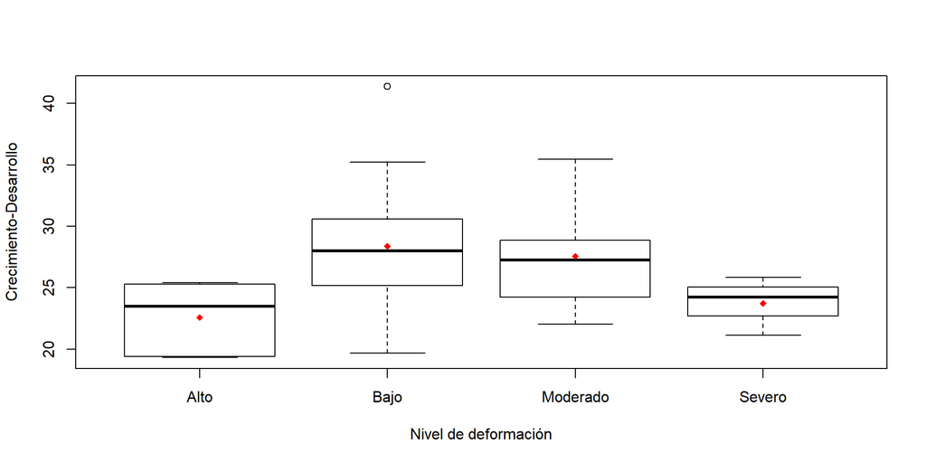

Mediante la prueba de Tukey de comparaciones múltiples de medias con un nivel de confianza al 95%, se concluye que el Crecimiento-Desarrollo es el mismo en los diferentes Niveles de deformación, y por lo tanto que la arquitectura de raíces con presencia de malformaciones o abultamientos irregulares en la base del tallo, no afecta el crecimiento y desarrollo de Taxodium mucronatum Ten.